# Divsersity in Action

[figure not shown]

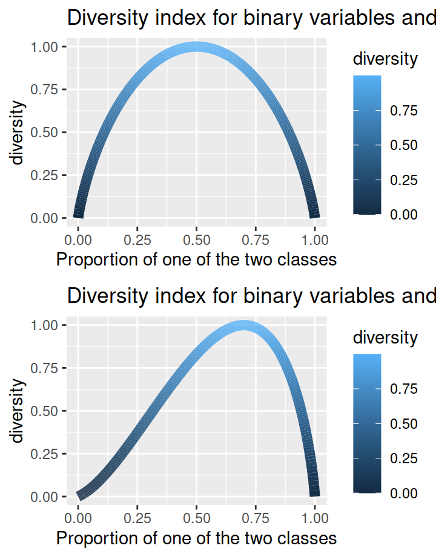

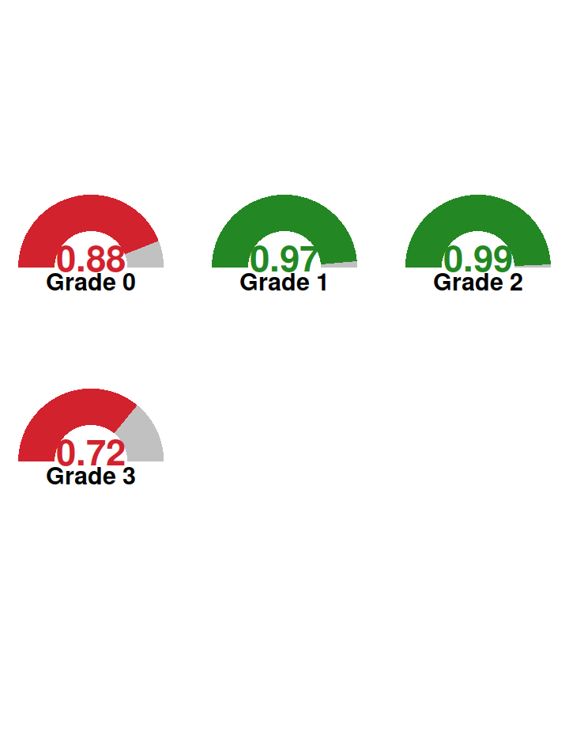

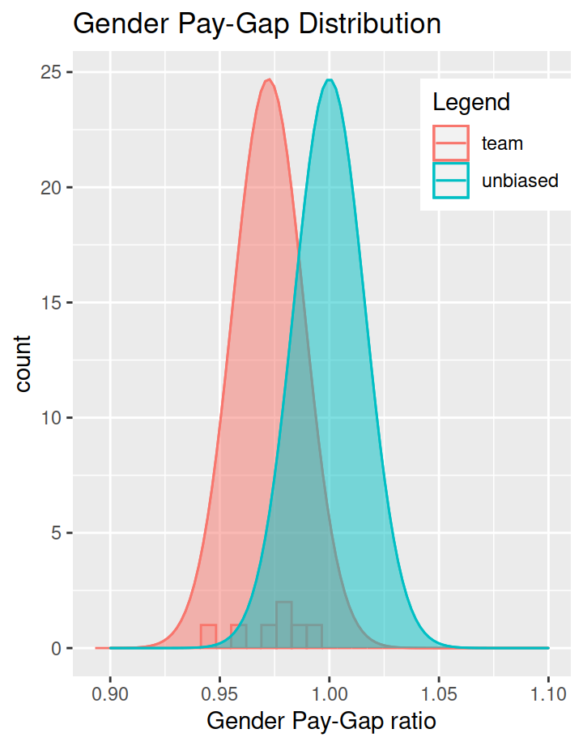

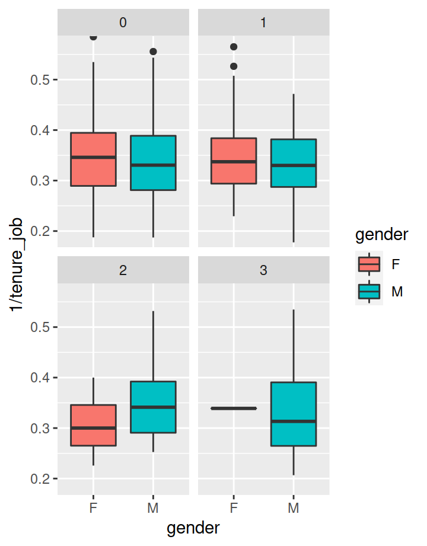

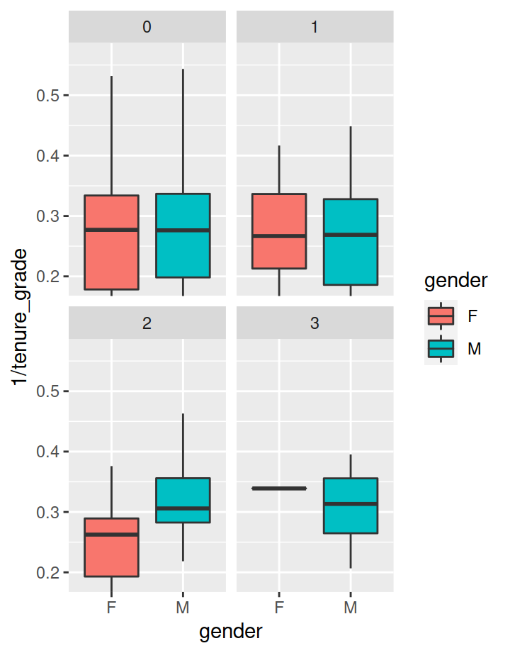

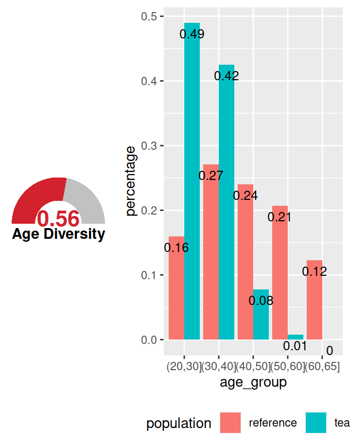

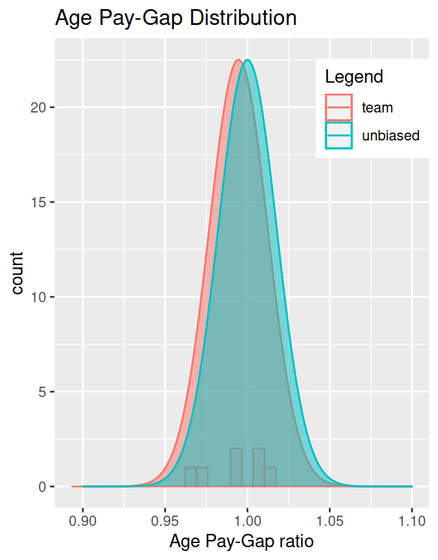

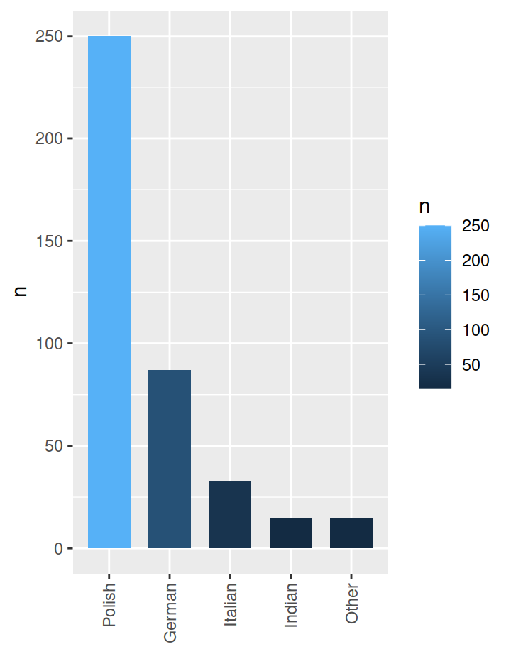

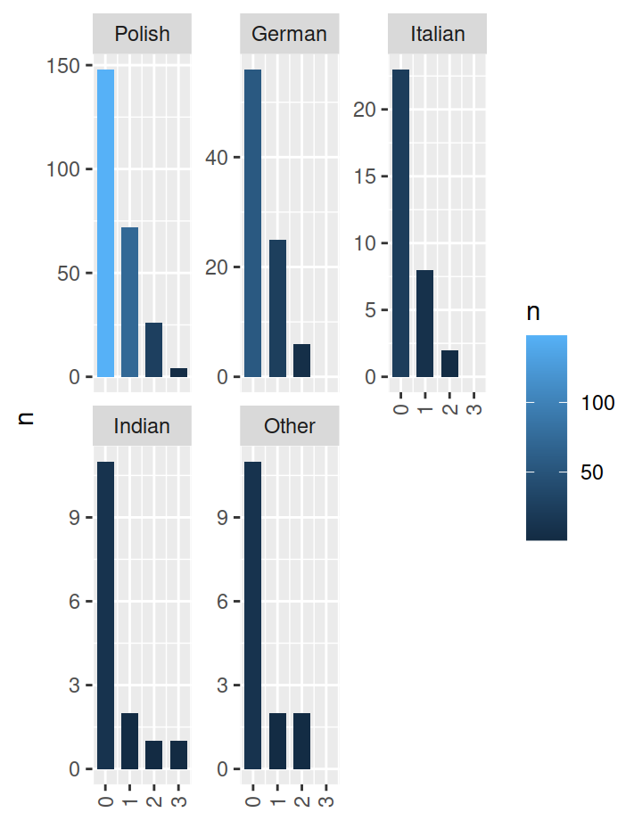

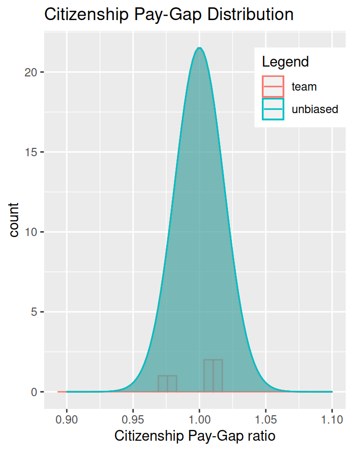

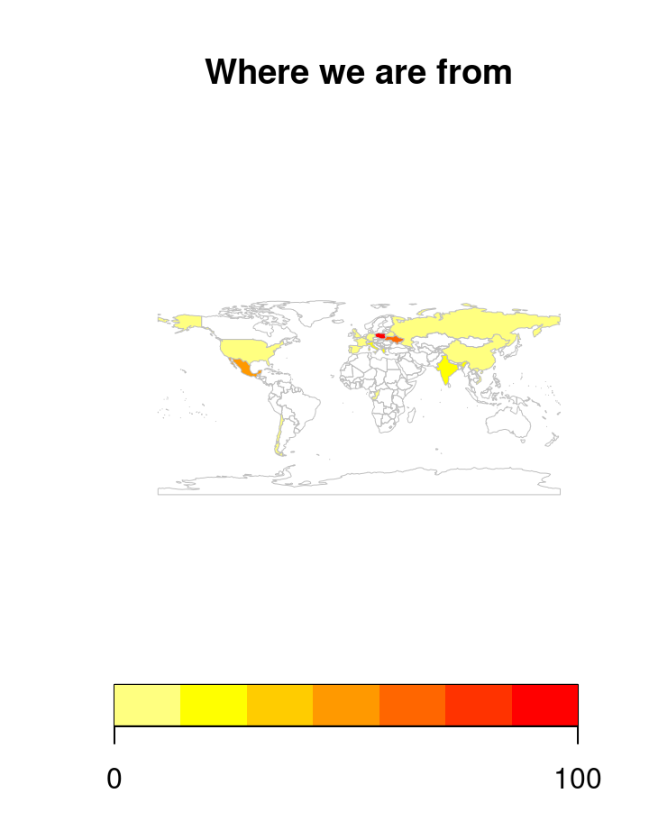

[1 more figures not shown]

# Overview

### Welcome! The Particular Example Behind this Demo Report

The data used for this report is randomly generated with the following characteristics:

- team size: 400
- percentage of females: 0.35
- average male’s salary / average female’s salary: 1.035
- no other biases are built in (so any other observations stem from random generation of data. This can be seen as “despite no bias against citizenship by the manager, some pay-gaps will be different from one.” This means that being unbiased is not necessarily the same as having equal outcomes.)

#### Equitable outcomes are not the same as equal outcomes!

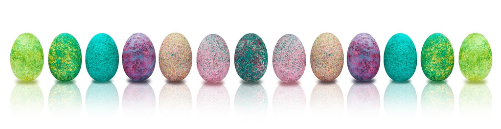

Welcome to the div dashboard for diversity and inclusion

### Findings: Salaries of females is systhematically lower than males in this young team. Consider also the following findings.

| Nbr | Area | Finding | Suggestion |
| --- | --- | --- | --- |
| 1 | Gender | Where we can calculate the paygap between females and non-females, we find that the females generally earn less in similar roles and similar grades. | Check the gender-paygap table and identify the grade/role combinations where an the paygap has most stars. Check if the salary differences are justified. |
| 2 | Age | The team is predominantly younger than the surrounding population (Poland). | Consider hiring older people to balance. Focus on retention. |
| 3 | Gender | The diversity is good in grade 1 and 2, but under par in grade 3 | Consider if females have barriers to apply to grade 3 jobs and remove the barriers. |
| 4 | Gender | Males in Grade 2 seem to have been promoted faster. | Understand unconscious bias, coach everyone (and specially females), work on trust. |

### Overview: illustrates the gender paygap over all teams and jobs

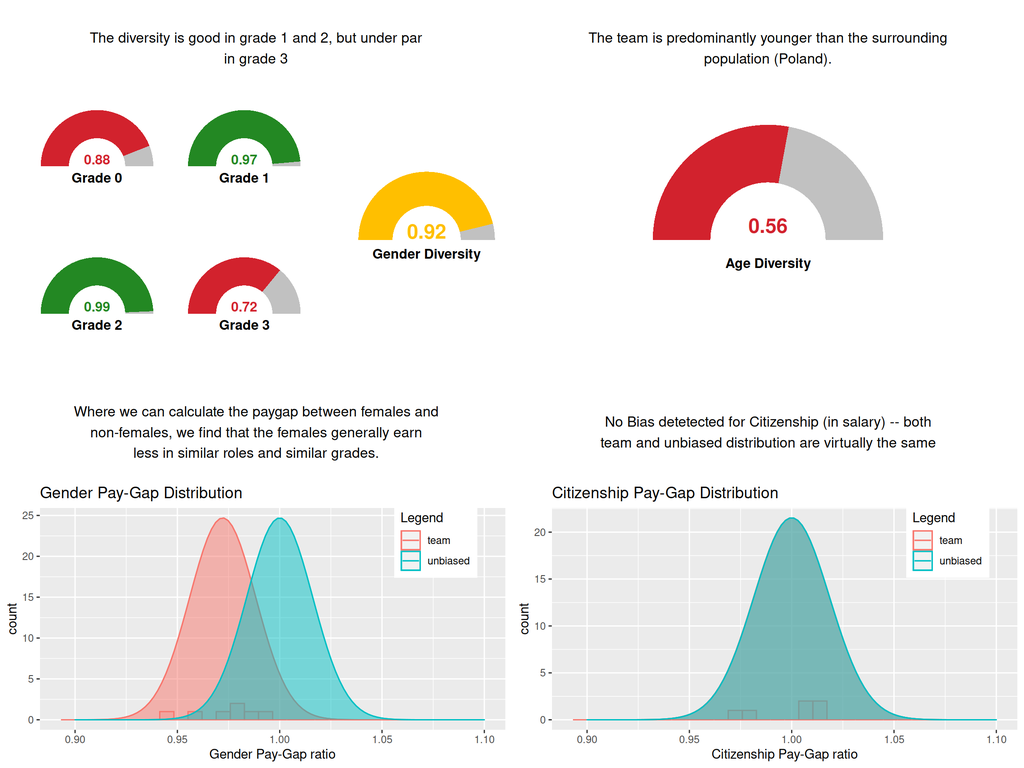

### Further information

#### Legends

- `paygap` = the ratio of median salaries of one group divided by the median of the salaries of the other group
- NA = numbers are too small, please look at individuals;
- = no bias detectable;
- . = maybe there is some bias, but the numbers are low, check individuals;
- * = you should check for bias;
- ** = bias is probably there;
- *** = most certainly there is bias

So, there will be more stars if the probability of a bias is higher: this can be due to a higher bias and/or due to a larger sample size.

- `grade` = the salary grade as used in the company
- `jobID` = a unique identifier of the job category (can be abbreviated)
- `sal_F` = the median salary of the females (F)
- `sal_oth` = the median salary of the other groups (non F). The tool is open to use more than one gender.
- `age_F` = the median age of the females (or `age_Pol` could be the median age of the team members with Polish citizenship)
- `age_oth` = the median age of the other groups take together (e.g. the median age of non females)
- `paygap` = the ratio of median salary earned by the selected group (e.g. females) divided by the median of the other people. If this is lower than $1$, then median female earns less than the median non-female.
- `conf.` = the confidence level that this paygap is significant.

#### The Diversity Index

We express diversity as a number between zero and one. Our calculation is based on “The Big R-Book” (and more in particular section 36.3.1 “The Business Case: a Diversity Dashboard”).

More details can be found in the book. The diversity indexes show how diverse our workforce is. It is calculated similar to entropy: $I = -\frac{1}{\log(N)} \sum_i^N {p_i \log p_i}$, where there are $N$ possible and mutually exclusive states $i$. They range from $0$ to $1$. Hence,

- The diversity is $0$ if only one of the groups is present, and is $1$ if both groups are equitably present.
- This calculation is similar to the established concept of entropy in physics.
- More than two categories can be used (e.g. one is not limited to two genders)
- We calibrate the probabilities so that they show maximum entropy (or diversity) for the percentages that naturally occur (see next slide).

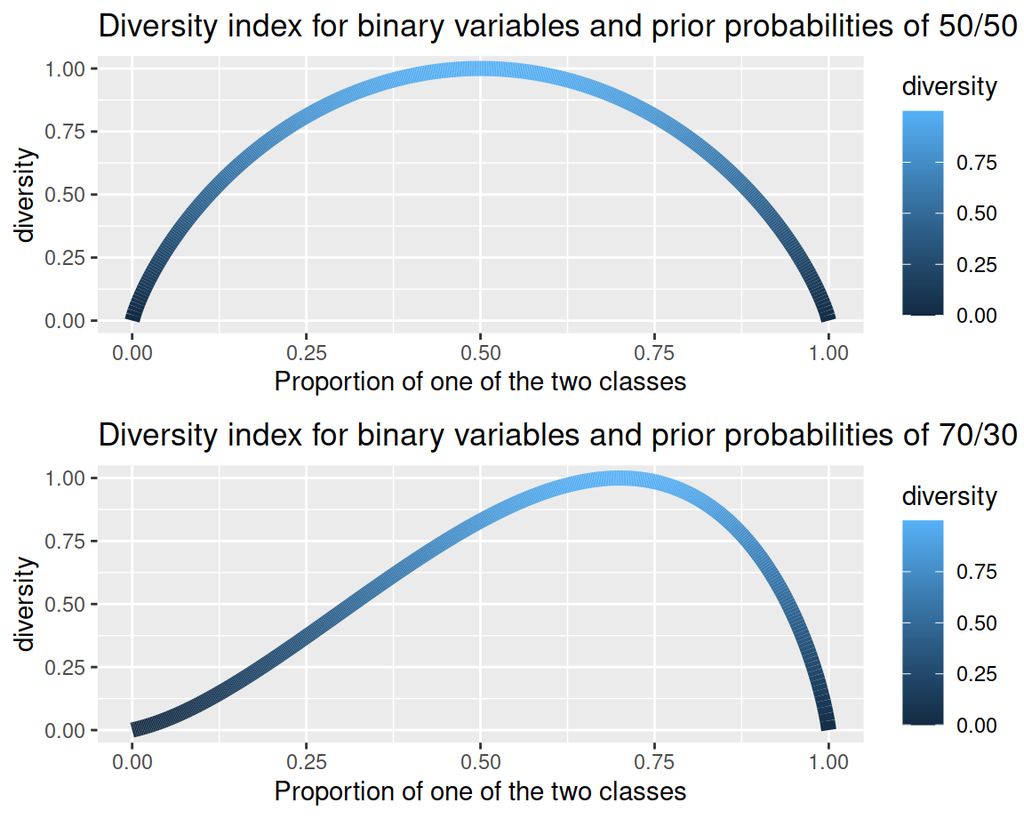

The diversity index illustrated for the case where there are only two possible classes, and where the prior priorities are respectively 50/50 (top) and 70/30 (bottom). The index reaches a maximum at a distribution equal to the prior probabilities.

#### The confidence level and p-value

The p-value is the probability that we make a mistake by assuming that there is no paygap.

It is calculated by splitting the data on a variable in binary factors (e.g. Females and others) and then checking how likely it is that a random person from the first group earns less than a random person from the second group. This is done by a method known as Mann-Whitney U test: [see Wikipedia](https://en.wikipedia.org/wiki/Mann%E2%80%93Whitney_U_test)[^1]

# Gender

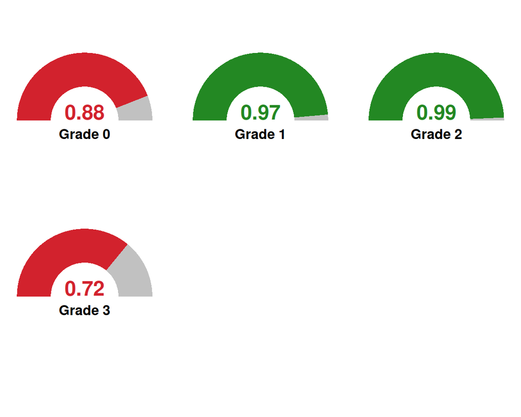

The diversity of the team with respect to gender per grade.

### Gender: the numbers. Every grade has a bias towards males.

Per group: numbers and medians for salary, age, tenure_firm, tenure_grade, tenure_job

| grade | gender | Nbr. | salary | age | tenure_firm | tenure_grade | tenure_job |
| --- | --- | --- | --- | --- | --- | --- | --- |
| 0 | F | 75 | 3,997 | 27.0 | 5.48 | 3.61 | 2.89 |
| 0 | M | 174 | 4,186 | 29.0 | 4.34 | 3.62 | 3.02 |
| 1 | F | 44 | 8,588 | 31.5 | 4.14 | 3.75 | 2.96 |
| 1 | M | 65 | 8,711 | 32.0 | 4.83 | 3.72 | 3.03 |
| 2 | F | 16 | 17,977 | 34.5 | 5.47 | 3.81 | 3.34 |
| 2 | M | 21 | 18,700 | 36.0 | 4.32 | 3.27 | 2.93 |
| 3 | F | 1 | 38,154 | 34.0 | 1.78 | 2.95 | 2.95 |
| 3 | M | 4 | 39,075 | 41.0 | 3.84 | 3.22 | 3.22 |

### The distribution of paygap. All paygaps, however go in the same direction. This is not good and needs to be addressed.

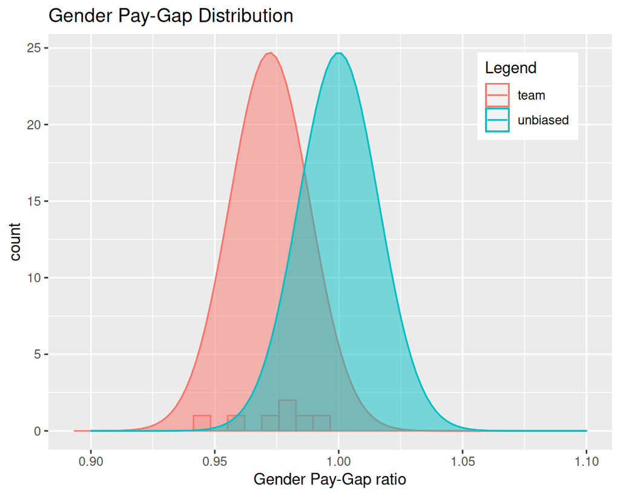

### The line-by-line paygap information reveals the places where ACTION is needed.

The paygap for gender (in terms of salary) as a ratio, along with the confidence level that this paygap is significant alongside the control variable age.

| grade | jobID | sal_F | sal_oths | n_F | n_oths | med_age_F | med_age_o | paygap | p-value | conf. |
| --- | --- | --- | --- | --- | --- | --- | --- | --- | --- | --- |
| 0 | sales | 3,902 | 4,133 | 51 | 105 | 28.0 | 29.0 | 0.944 | 0.00865 | ** |
| 2 | sales | 17,971 | 18,737 | 12 | 16 | 34.5 | 35.5 | 0.959 | 0.00067 | *** |
| 3 | sales | 38,154 | 39,326 | 1 | 3 | 34.0 | 39.0 | 0.970 | 0.50000 |  |
| 1 | analytics | 8,500 | 8,703 | 17 | 24 | 31.0 | 32.0 | 0.977 | 0.09287 | . |
| 2 | analytics | 18,022 | 18,443 | 4 | 5 | 37.0 | 36.0 | 0.977 | 0.06349 | . |
| 0 | analytics | 4,177 | 4,229 | 24 | 69 | 27.0 | 29.0 | 0.988 | 0.39684 |  |
| 1 | sales | 8,625 | 8,712 | 27 | 41 | 32.0 | 31.0 | 0.990 | 0.34961 |  |
| 3 | analytics | NA | 38,825 | 0 | 1 | NA | 43.0 | NA | NA | NA |

### Boxplots for salary show another view on the paygap. The box in the barplot shows the bulkd of the observations (second and third quartile) and the line in its middle is the median.

[interactive chart not shown]

### Job Changes per Year per Gender

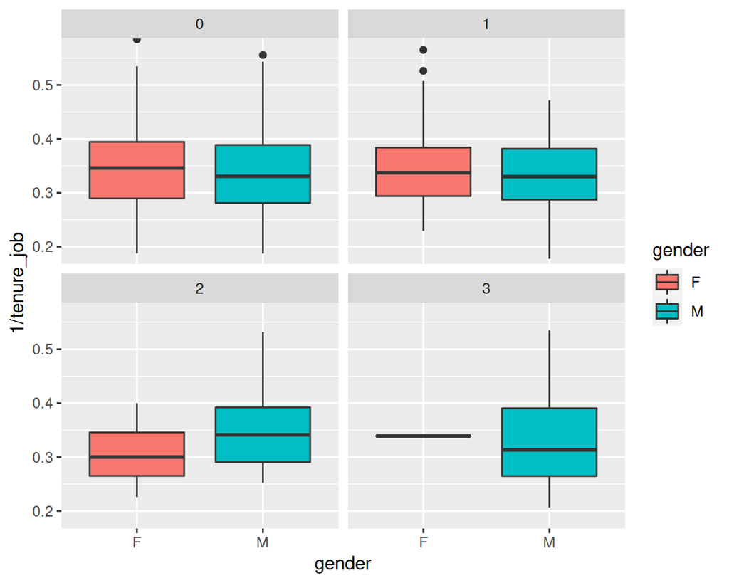

### Promotions per Year per Gender

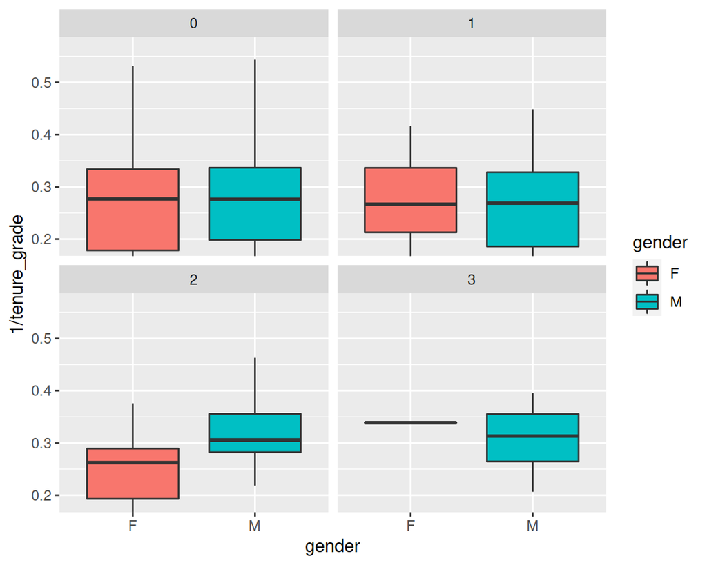

The number of promotions per year can show if a gender is more probable to be promoted.

### Conclusions for gender diversity and inclusion – the main findings are:

| Nbr | Finding | Suggestion |
| --- | --- | --- |
| 1 | Where we can calculate the paygap between females and non-females, we find that the females generally earn less in similar roles and similar grades. | Check the gender-paygap table and identify the grade/role combinations where an the paygap has most stars. Check if the salary differences are justified. |
| 3 | The diversity is good in grade 1 and 2, but under par in grade 3 | Consider if females have barriers to apply to grade 3 jobs and remove the barriers. |
| 4 | Males in Grade 2 seem to have been promoted faster. | Understand unconscious bias, coach everyone (and specially females), work on trust. |

# Age

### The team is relatively young when we compare with the general surrounding population.

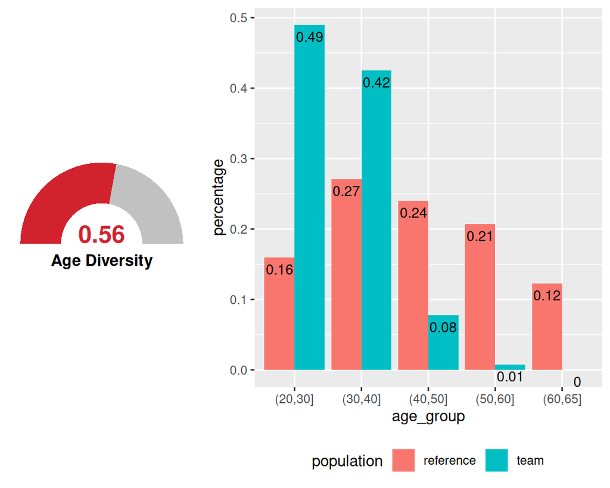

The diversity of the team with respect to age, assuming the age distribution of the country as reference.

### The distribution of age paygap reveals no systhematic bias.

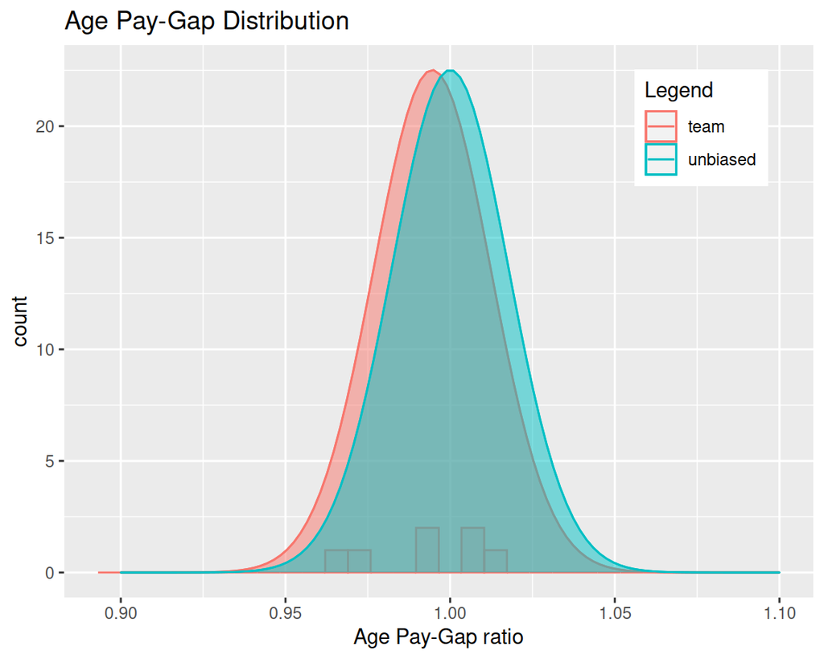

### The Age Paygap details reveal one grade/job where we might want to check.

The paygap for age (in terms of salary) as a ratio, along with the confidence level that this paygap is significant alongside the control variable age.

| grade | jobID | sal_L | sal_H | n_L | n_H | med_age_L | med_age_H | paygap | p-value | conf. |
| --- | --- | --- | --- | --- | --- | --- | --- | --- | --- | --- |
| 1 | analytics | 8,465 | 8,741 | 19 | 22 | 26.0 | 35.0 | 0.968 | 0.0563 | . |
| 2 | sales | 18,130 | 18,584 | 14 | 14 | 32.0 | 40.5 | 0.976 | 0.1636 |  |
| 3 | sales | 38,740 | 39,115 | 2 | 2 | 34.5 | 43.5 | 0.990 | 0.6667 |  |
| 0 | analytics | 4,200 | 4,221 | 40 | 53 | 25.0 | 32.0 | 0.995 | 0.5684 |  |
| 1 | sales | 8,676 | 8,609 | 34 | 34 | 29.5 | 36.0 | 1.008 | 0.6920 |  |
| 2 | analytics | 18,270 | 18,112 | 4 | 5 | 32.0 | 42.0 | 1.009 | 0.4127 |  |
| 0 | sales | 4,106 | 4,042 | 72 | 84 | 24.0 | 32.0 | 1.016 | 0.3407 |  |
| 3 | analytics | NA | 38,825 | 0 | 1 | NA | 43.0 | NA | NA | NA |

### Conclusions for age diversity and inclusion – the main findings are:

| Nbr | Finding | Suggestion |
| --- | --- | --- |
| 2 | The team is predominantly younger than the surrounding population (Poland). | Consider hiring older people to balance. Focus on retention. |

# Citizenship

### Most people are Polish

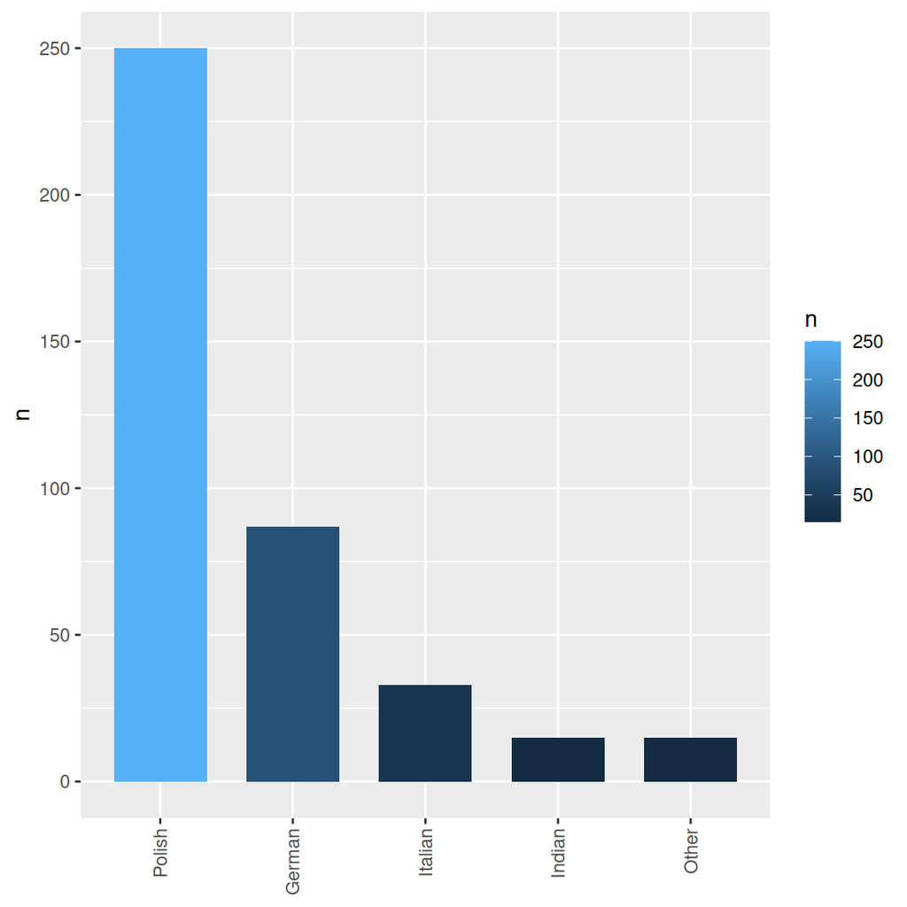

The barplot for the nationalities in the team over all grades.

### No anomalies can be detected for the distribution per grade

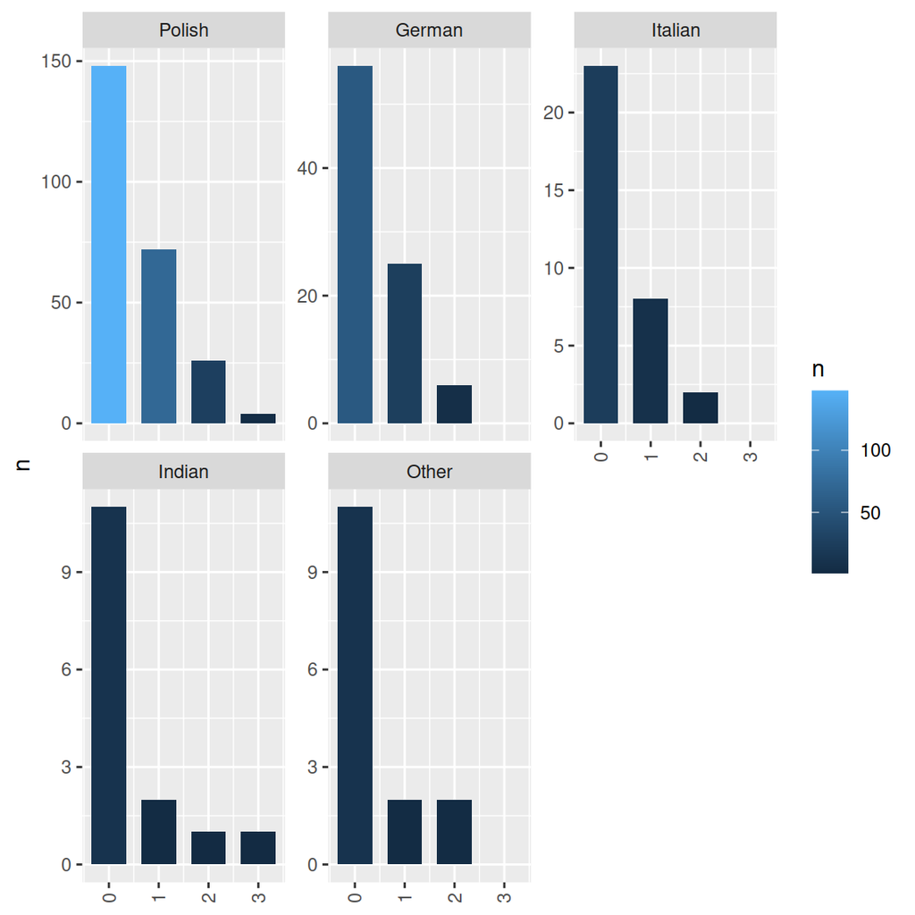

The breakdown of each grade per nationalitiy.

### The distribution of citizen paygap reveals no systhematic bias.

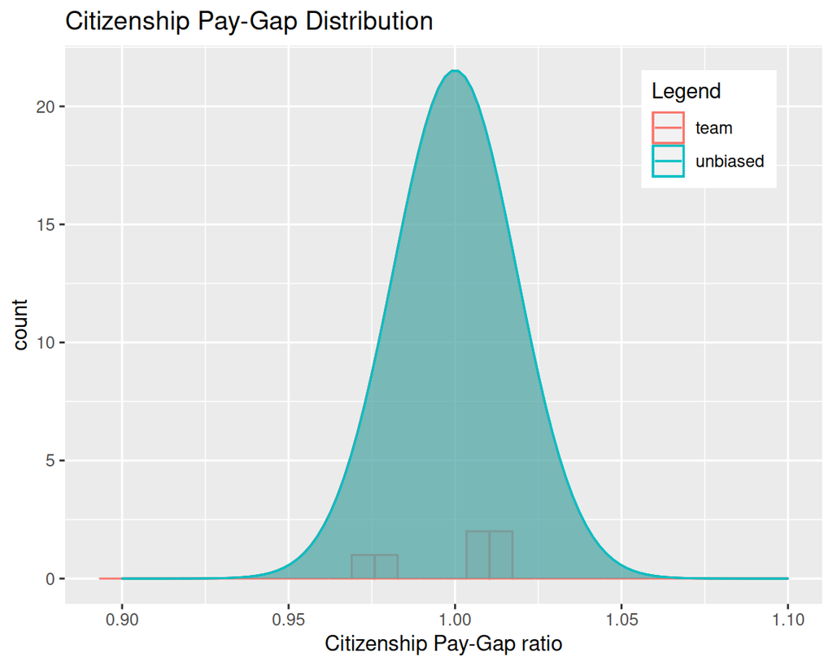

### The Citizenship PayGap: no actions needed.

The paygap for citizenship (in terms of salary) as a ratio, along with the confidence level that this paygap is significant alongside the control variable age.

| grade | jobID | sal_Polis | sal_oths | n_Polish | n_oths | med_age_P | med_age_o | paygap | p-value | conf. |
| --- | --- | --- | --- | --- | --- | --- | --- | --- | --- | --- |
| 2 | sales | 18,244 | 18,700 | 19 | 9 | 34.0 | 36.0 | 0.976 | 0.308 |  |
| 1 | analytics | 8,560 | 8,761 | 26 | 15 | 32.5 | 30.0 | 0.977 | 0.695 |  |
| 0 | analytics | 4,227 | 4,193 | 56 | 37 | 28.5 | 28.0 | 1.008 | 0.275 |  |
| 0 | sales | 4,078 | 4,042 | 92 | 64 | 27.0 | 29.0 | 1.009 | 0.664 |  |
| 2 | analytics | 18,207 | 17,947 | 7 | 2 | 35.0 | 39.0 | 1.014 | 0.889 |  |
| 1 | sales | 8,702 | 8,569 | 46 | 22 | 32.5 | 30.5 | 1.016 | 0.554 |  |
| 3 | sales | 39,035 | NA | 4 | 0 | 37.0 | NA | NA | NA | NA |
| 3 | analytics | NA | 38,825 | 0 | 1 | NA | 43.0 | NA | NA | NA |

### rworldmap

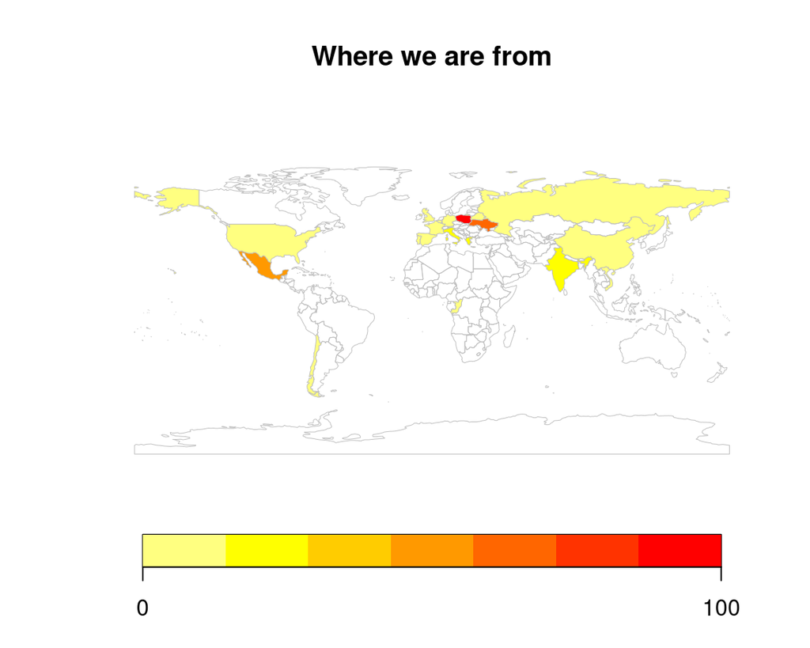

### leaflet

[interactive chart not shown]

# Tenure in Firm

### The distribution of Tenure in the Company paygap reveals no systhematic bias.

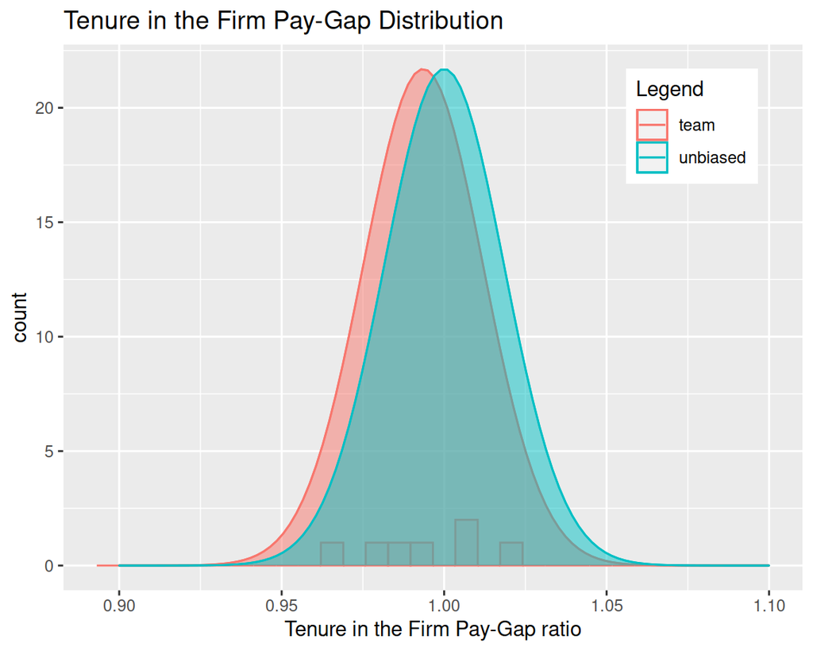

### We do not pay new employees more than loyal ones

The paygap for tenure firm (in terms of salary) as a ratio, along with the confidence level that this paygap is significant alongside the control variable age.

| grade | jobID | sal_L | sal_H | n_L | n_H | med_age_L | med_age_H | paygap | p-value | conf. |
| --- | --- | --- | --- | --- | --- | --- | --- | --- | --- | --- |
| 1 | sales | 8,566 | 8,854 | 34 | 34 | 33.0 | 31.0 | 0.968 | 0.0783 | . |
| 0 | sales | 4,040 | 4,125 | 78 | 78 | 28.0 | 28.0 | 0.979 | 0.6147 |  |
| 2 | sales | 18,228 | 18,535 | 14 | 14 | 35.5 | 35.0 | 0.983 | 0.8743 |  |
| 3 | sales | 38,740 | 39,115 | 2 | 2 | 34.5 | 43.5 | 0.990 | 0.6667 |  |
| 0 | analytics | 4,237 | 4,207 | 46 | 47 | 28.0 | 28.0 | 1.007 | 0.8658 |  |
| 2 | analytics | 18,270 | 18,112 | 4 | 5 | 32.0 | 42.0 | 1.009 | 0.5556 |  |
| 1 | analytics | 8,652 | 8,495 | 20 | 21 | 33.5 | 30.0 | 1.018 | 0.7053 |  |
| 3 | analytics | NA | 38,825 | 0 | 1 | NA | 43.0 | NA | NA | NA |

[^1]: The Mann–Whitney U test (aka. Mann–Whitney–Wilcoxon (MWW), Wilcoxon rank-sum test, or Wilcoxon–Mann–Whitney test) is a nonparametric test of the null hypothesis that, for randomly selected values X and Y from two populations, the probability of X being greater than Y is equal to the probability of Y being greater than X. If we assume that the distributions are symmetric, it boils down to a test that the medians are different.